# RuDiPro – rhythm

## Церковное (Говор 52)

Безударный вокализм после твердых согласных – **полное оканье**: гласные на месте этимологических **о* и **а* различаются во всех безударных слогах:

- *Разогреешь, посолишь немножко* (церк29)
- *И вот там человек один лошадь обгоняет, топчет* (церк15)
- *Он холодный!* (церк14)
- *И вот работаем, а тебя заставляют – пиши!* (церк13)
- *По две коровы кормили, а кто хорошо…* (церк15)
- *Всех леший унёс, поразнёс…* (церк7)

Ритмическая структура слова без противопоставления 1-го предударного слога остальным безударным слогам (см. Рисунок 1).

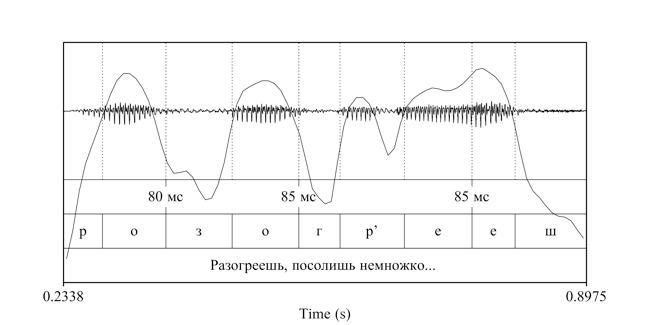

(a)

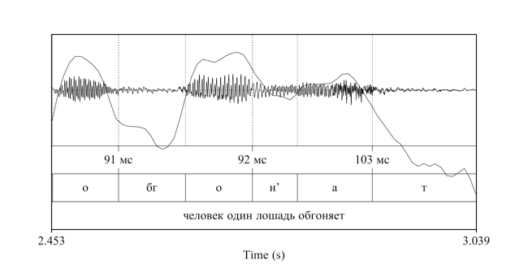

(b)

Рисунок 1: Осциллограмма и огибающая интенсивности слов *разогреешь* (слева) и *обгоняет* (справа)

Безударный вокализм после мягких согласных – частичное различение гласных на месте этимологических гласных неверхнего подъема **ѣ*, **а* и **е*, *ь* (см. Таблица 1).

1. Перед твердыми согласными в 1-м предударном слоге
   - на месте **ѣ* произносится [е]:

   *Куды, думаю, все люди девалися?* (ц24),

   *А в Андронихи двенадцать домов было, деревня была* (ц23);
   - на месте **а* произносится [е]:

   *Лягух нету, нет, нету* (ц34),

   *Вязать я вяжу, так вязала* (ц41),

   *– Чтобы лучше писать водили? – Плясать! – А, плясать. – Но. Плясать* (ц01);
   - на месте **е*, *ь* произносится [о] (реже [е]):

   *Александрой зовут-то ей* (ц40),

   *Уехала там к сестры* (ц37),

   *Одна свекрова, другая мать* (ц26),

   *Она там лежит* (ц20).
2. Перед мягкими согласными в 1-м предударном слоге
   - на месте **ѣ* произносится [и]:

   *Сейчас в реки-то рыбы-то нету* (ц31),

   *А раньше чего, в реки и рыбы-то много* (ц30),

   *Это нацедят молока-то* (ц27),

   *И от рака-то умерла, двое детей оставила* (ц04);
   - на месте **а* произносится [е]:

   *А потом говорят: «Что за беда, что за снарядиха?»* (ц22),

   *Кастрюлю на плитку, его перекипячу…* (ц19),

   *Срядилася дак* (ц02);
   - на месте **е*,* ь* произносится [е]:

   *Запекёшь такие* (ц33),

   *Там пахали дак ручеёк экой маленькой* (ц32),

   *А в Андронихи двенадцать домов было, деревня была* (ц23),

   *Дак теперь уж-то мне восьмидесятый год, дак леший знает!* (ц10),

   *Пойду перекрестясь* (ц05).

Таблица 1: Безударный вокализм 1-го предударного слога после мягких согласных

| примеры | перед С |  | перед С’ | примеры |
| --- | --- | --- | --- | --- |
| *девалися*, *двенадцать* | [е] | **ѣ* | [и] | *реки*, *нацедят*, *детей* |
| *лягух*, *плясать*, *вязать*, *вяжу*, *вязала* | [е] | **а* | [е] | *снарядиха*, *перекипячу*, *срядилася* |
| *Александрой*, *сестры*, *свекрова*, *лежит* | [о] | **е, ь* | [е] | *запекёшь*, *деревня*, *ручеёк*, *теперь* |

Широко представлено заударное ёканье (произношение [о] на месте этимологических **е*, *ь*), особенно последовательно — в окончаниях глаголов:

*Там много, она вяжет* (ц39),

*И вот там человек один лошадь обгоняет, топчет* (ц15),

*Дак теперь уж-то мне восьмидесятый год, дак леший знает!* (ц10).

См. Описание говора.

## Тамбовский (Говор 13)

### Верхнеспасское

Говор с. Верхнеспасское был обследован по программе ДАРЯ сотрудниками Института русского языка АН СССР в 1965 г. Согласно этим данным, предударный вокализм после твёрдых согласных в нём – недиссимилятивное аканье, а после мягких – ассимилятивно-диссимилятивное яканье новосёлковского типа ([и] в первом предударном слоге произносится перед ударными /е/ и [’о], [а] – перед остальными гласными (Аванесова, Бромлей 1986: карты 3, 8)).

| П/у гласный | Дл-ть п/у гласного | Уд. гласный | Дл-ть уд. гласного | Дл-ть п/у гласного в % от дл-ти ударного |
| --- | --- | --- | --- | --- |
| а | 99 | и ы у | 134 | 79 |
| а | 96 | ô ê | 141 | 73 |
| а, ъ | 94 | о ’о е | 141 | 70 |
| а, ъ | 93 | а | 148 | 67 |

Аудитивный анализ показывает, что перед ударными гласными [а], а также [е] и [о], не восходящими к *ѣ и* ω, наряду с [а] возможен предударный [ъ], в других позициях – только [а]. По-видимому, система аканья верхнеспасского говора в прошлом предполагала диссимилятивную зависимость предударных гласных от ударных.

В безударных слогах непервого предударного слога после твёрдых согласных [ъ]:

*Во как попал-то* (всп01)

*Пойдём за книжкой* (всп17)

*Жена не говори мужу ничё* (всп03)

*Их забрали на войну* (всп06)

*Ты что думаешь, шут на омёт подать навильник?* (всп39)

*Какой клочок купишь или там что-нибудь* (всп40)

*Сейчас поросят берут, быков кормят, ну а тоды-то не было, если есть одна корова – всё вот* (всп41)

*Сестра тогда по вербовке уехала – мне ровесница* (всп42)

*Молоком горячим* (всп43)

*А я говорю: «Я неграмотная!»* (всп12)

*Зина-то – это ещё ходила, она на бухгалтера выучилась* (всп19)

*Две лощины или три до табора-то* (всп31)

В некоторых случаях в заударных слогах выступает а-образный звук, к таковым относятся позиции перед [й] в

- окончании И.п. м.р. прилагательных,
- окончании Тв.п. существительных 1 скл.:

*Там Егорка родной* (всп08)

*Пойдём за книжкой* (всп17)

Встречаются примеры редукции до нуля и почти до нуля в заударных и втором предударном слогах.

*Трое ребятишечек было* (всп09)

*Да, я тоже тутошная* (всп11)

*Хорошо, что ли* (всп33)

С другой стороны, в позиции после шумных согласных перед плавными возможен вставной гласный [ъ]:

*И мы не пухли* (всп44)

*На дню три раза* (всп45)

В начальном неприкрытом втором предударном слоге встречается звук [и]:

*Дети, вот только один зять озорной это, деревенский-то* (всп38)

Данные перцептивного анализа безударного вокализма после мягких согласных (460 примеров, информанты МГЛ1934 и ДГЛ1919; Таблица 3, Рисунок 2) свидетельствуют о том, что в нём наблюдается очень сложная картина: совмещение

1. диссимилятивного принципа (более долгий предударный гласный перед ударными верхнего и (этимологически) верхне-среднего подъёма) с
2. ассимилятивным (более «полный» гласный перед ударным [а]) и с
3. принципом умеренного вокализма (более передний предударный перед мягким согласным, чем перед твёрдым).

Таблица 3: Яканье в говоре Верхнеспасского (индекс обозначает количество соответствующих примеров в процентах от общего числа)

[output not shown]

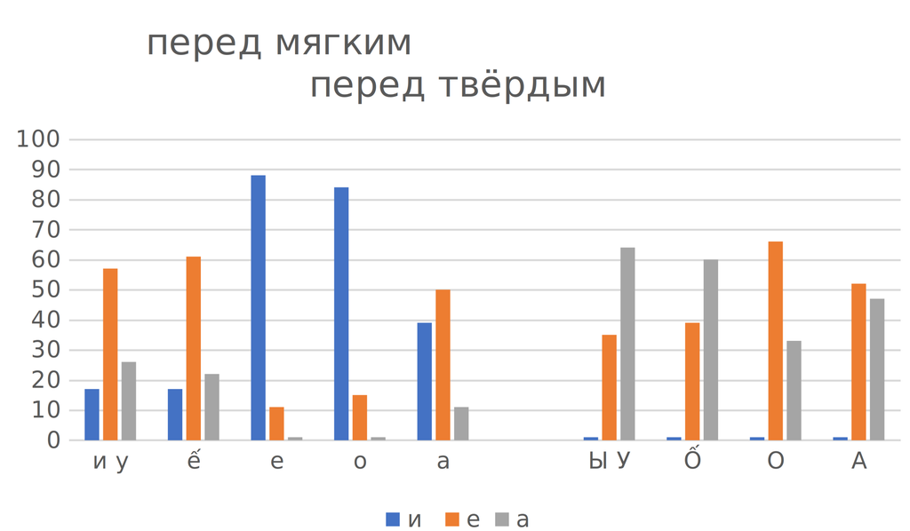

Рисунок 2: Количество (в % от общего числа) примеров произношения гласных [а], [е], [и] в первом предударном слоге после мягких согласных в зависимости от ударного гласного и твёрдости/мягкости согласного перед ним

Примеры:

- перед ударными гласными верхнего и (этимологически) верхне-среднего подъёма (сначала перед твёрдыми согласными, затем перед мягкими):

*И ребятишки у нас, чтоб вон от одной матери есть – дерутся, туды= у нас – никогда* (всп07)

*И на пятерых дадут нам одну книжку* (всп16)

*Вот Бездушный там у нас был* (всп20)

*Эти корешки-то – суп варили* (всп25)

*Все под запертой живут-то* (всп02)

*Там Егорка родной* (всп08)

*А мы с сестрой с двадцать девятого, а я с тридцать четвёртого, что там мне было* (всп21)

*Мы масло продавали пахтали, на зерно, на крупу* (всп24)

*Разуваемся, переходим* (всп30)

*Тут ребёночек у нас появился* (всп04)

*И ребятишки у нас, чтоб вон от одной матери есть – дерутся, туды= у нас – никогда* (всп07)

*Трое ребятишечек было* (всп09)

*Не призведи лихому татарину такую жизнь, какую мы переживали* (всп28)

*Мы тоже не ели* (всп22)

*Доманька велела, тут у ней где-то четвёрка вина, велела отдать* (всп35)

*Да ты велела Барбину её отдать* (всп36)

*И через плечо, вот как* (всп15)

- перед ударными среднего подъёма:

*А сумки шили из мешочков вот* (всп14)

*Каждый день ходили на табор пешком взад-вперёд* (всп26)

*Верхом сядут, да за нами* (всп29)

*А я у дочери, тут, в деревне, живу зиму-ту* (всп37)

*Дети, вот только один зять озорной это, деревенский-то* (всп38)

*Разведём…* (всп13)

*Тут ребёночек у нас появился* (всп04)

*А мы с сестрой с двадцать девятого, а я с тридцать четвёртого, что там мне было* (всп21)

*Каждый день ходили на табор пешком взад-вперёд* (всп26)

*Доманька велела, тут у ней где-то четвёрка вина, велела отдать* (всп35)

- перед ударным нижнего подъёма:

*Война началась, я уж расскажу* (всп05)

*И убегает* (всп10)

*А я говорю: «Я неграмотная!»* (всп12)

*Бывало, накосим с ней по вязаночке* (всп27)

*Мы попадаем в дверях* (всп18)

*И меняла всё* (всп23)

*А мы с сестрой с двадцать девятого, а я с тридцать четвёртого, что там мне было* (всп21)

В безударных слогах непервого предударного слога после мягких согласных фонемы неверхнего подъёма совпадают в звуке [ь]:

*И ребятишков сколько много было* (всп32) *И не дай бог никому такую жизнь, какую мы пережили* (всп34) *Дети, вот только один зять озорной это, деревенский-то* (всп38)

Ритмическая структура предполагает противопоставление 1-го предударного слога остальным безударным слогам, в частности, 2-му предударному, по длительности и интенсивности (см. Рисунок 3), однако эта двухступенчатость выражена слабее, чем, например, в южнорусских говорах с диссимилятивными типами вокализма, см. (Высотский 1973: 37).

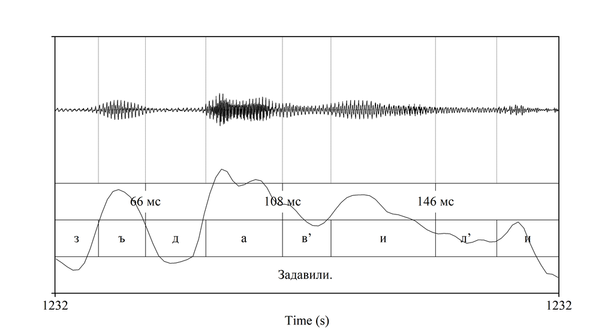

(a)

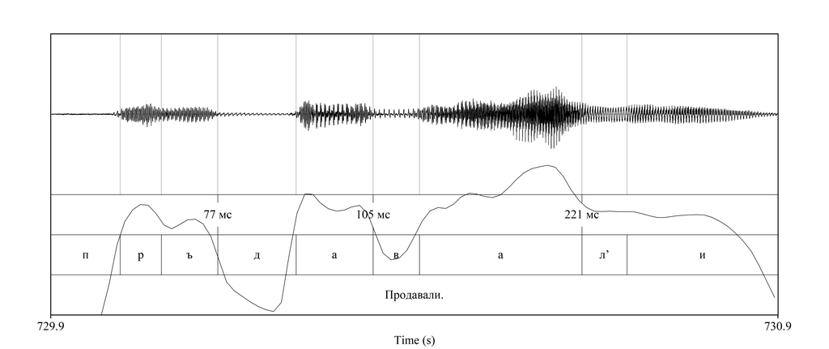

(b)

См. Описание говора.

## Список литературы

Аванесова, Р. И., Бромлей, С. В. (1986). *Диалектологический атлас русского языка. Центр европейской части СССР. Выпуск I: фонетика*. М.: Наука.

Высотский, С. С. (1973). О звуковой структуре русских говоров. In С. В. Бромлей (Ed.), *Исследования по русской диалектологии* (pp. 17–41). М.

Князев, С. В., Шаульский, Е. В. (2007). Генезис диссимилятивного аканья (в связи с проблемой фонологизации фонетических явлений). *Русский Язык в Научном Освещении*, *1*(13), 209–224.